# Лабораторная работа №1

## 4. Установка программного обеспечения

Устанавливаю pandoc.

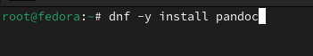

Установка pandoc

## 4. Установка программного обеспечения

Устанавливаю дополнения для pandoc, а pandoc crossref, скачиваю с github, распаковываю и помещаю в папку usr/local/bin.

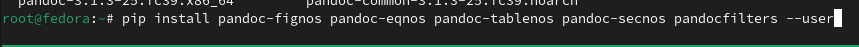

Установка расширений для pandoc

## 4. Установка программного обеспечения

Устанавливаю TexLive.

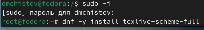

Установка TexLive

## 5. Дополнительные задания

С помощью grep получаю информацию о версии ядра.

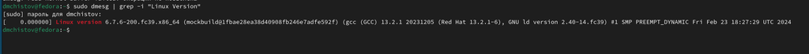

## 5. Дополнительные задания

Также получаю информацию о частоте процессора, его модели, об объёме доступной памяти, о типе обнаруженного гипервизора, типе файловой системы корневого раздела, о последовательности монтирования файловых систем.

## 5. Дополнительные задания

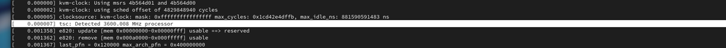

Частота процессора - 3600Мгц

## 5. Дополнительные задания

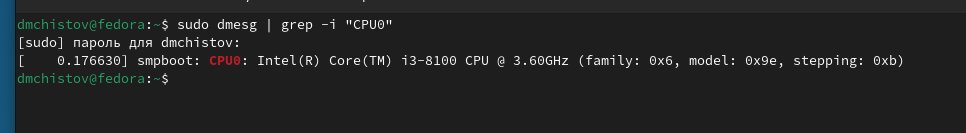

Модель процессора

## 5. Дополнительные задания

[figure not shown]

Объём доступной памяти - 3963432K/4103848K

## 5. Дополнительные задания

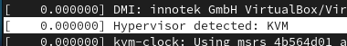

Тип обнаруженного гипервизора

## 5. Дополнительные задания

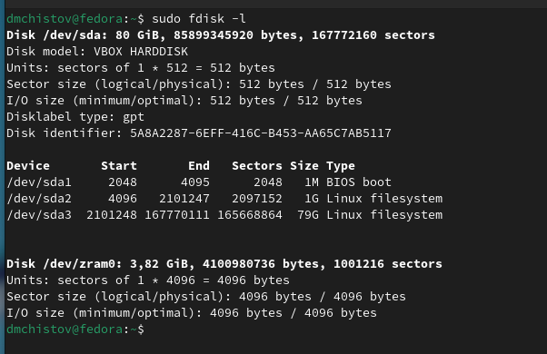

Тип файловой системы корневого раздела

## 5. Дополнительные задания

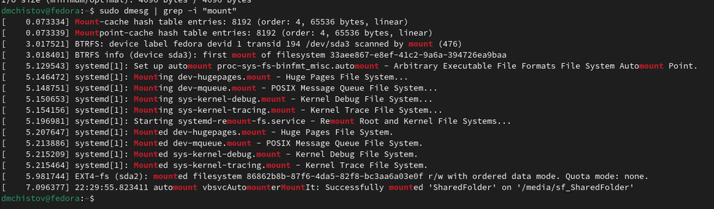

Последовательность монтирования файловых систем

# Выводы

Выполняя данную лабораторную работы я приобрёл навыки установки операционной системы на виртуальную машину, настройки минимально необходимых для дальнейшей работы сервисов.

# Список литературы

[Лабораторная работы №1](https://esystem.rudn.ru/mod/page/view.php?id=1098787)